# Datenvisualisierung mit R

Trends im Zeitverlauf

Armin Schäfer

schaefer@politik.uni-mainz.de

03.07.2025

# Themes anpassen

## Überblick

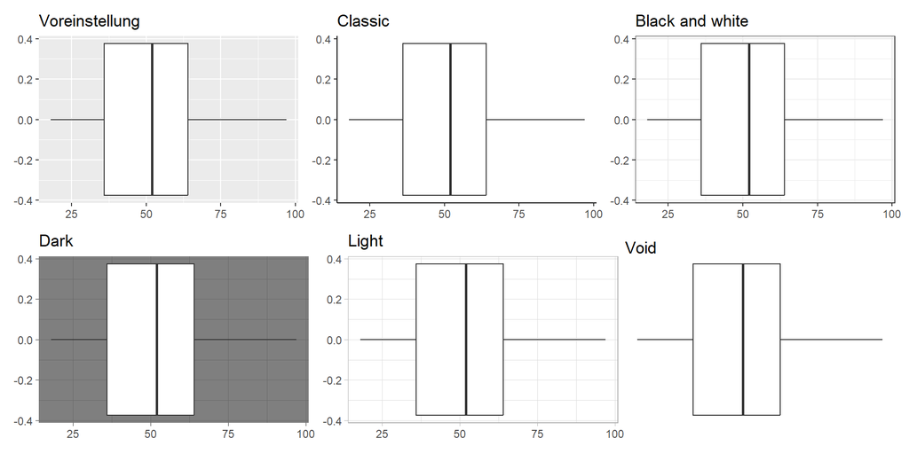

## Elemente von `themes()`

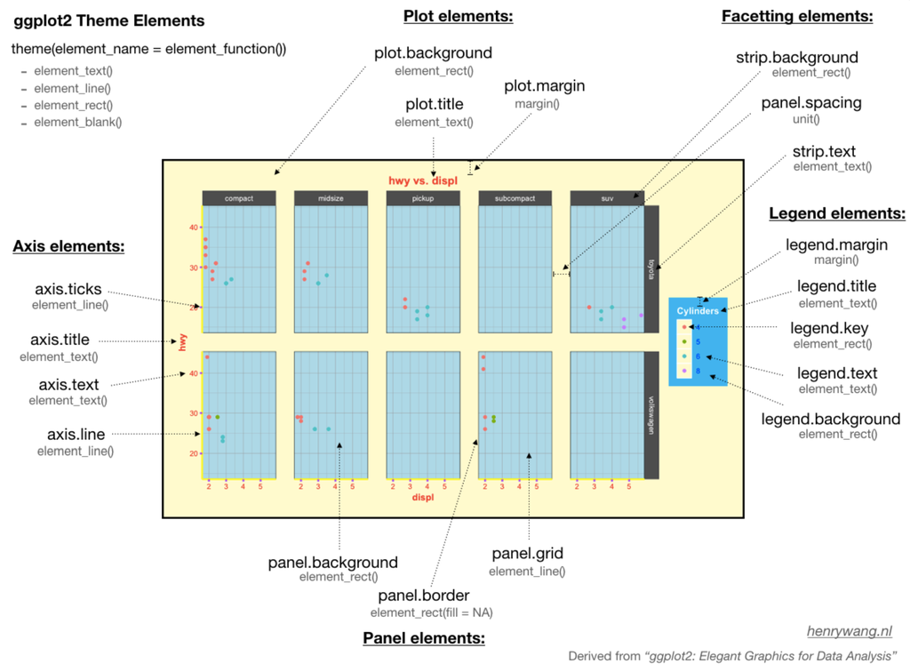

Quelle: [Henry Wang](https://henrywang.nl/ggplot2-theme-elements-demonstration/)

## Theme: Ausgangspunkt

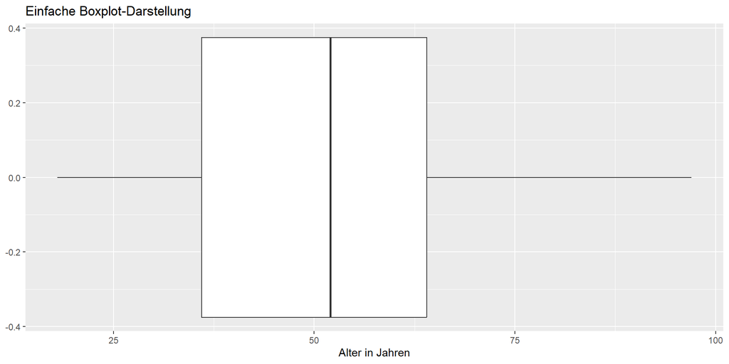

```r
p1 <- ggplot(data = ces, aes(x = age))+
  geom_boxplot()+
  labs(x = "Alter in Jahren", title = "Einfache Boxplot-Darstellung")

p1
```

## Theme: Achsen-Beschriftung anpassen

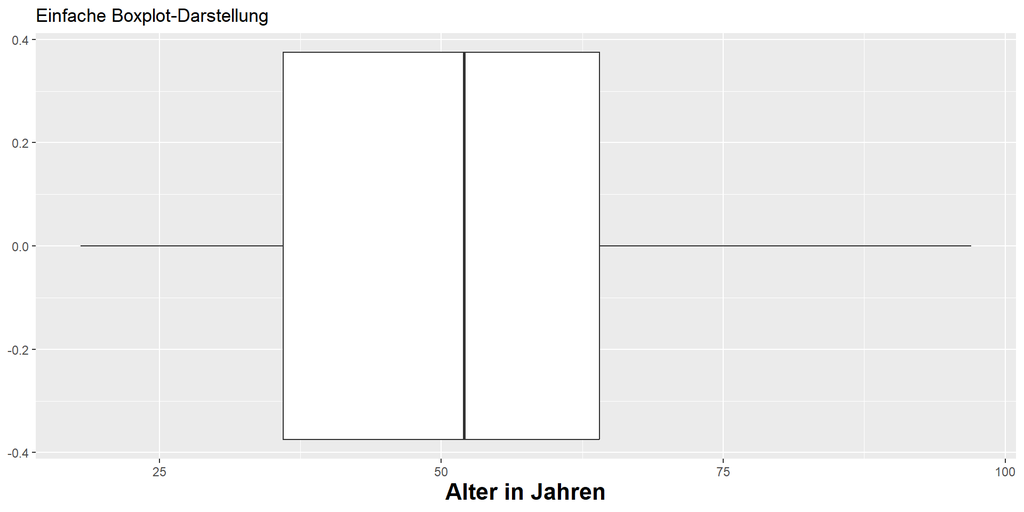

```r
p1 +
  theme(axis.title = element_text(face = "bold", size = 16))
```

## Theme: Achsen-Beschriftung anpassen

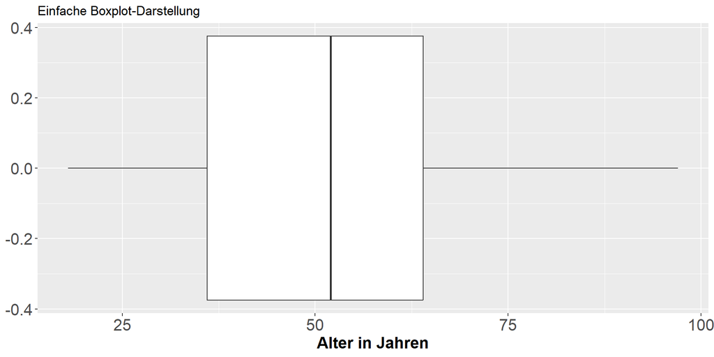

```r
p1 +
  theme(axis.title = element_text(face = "bold", size = 16),
        axis.text  = element_text(size = 16))
```

## Theme: Titel anpassen

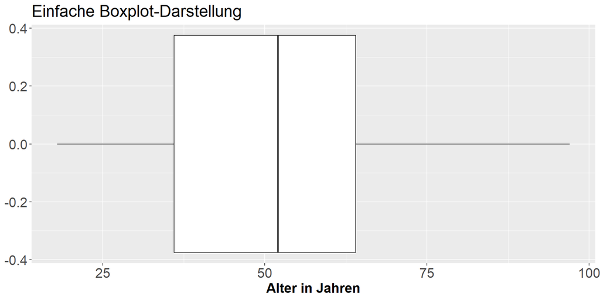

```r
p1 +
  theme(axis.title = element_text(face = "bold", size = 16),
        axis.text  = element_text(size = 16),
        plot.title = element_text(size = 20))
```

## Theme: Grid-Linien anpassen

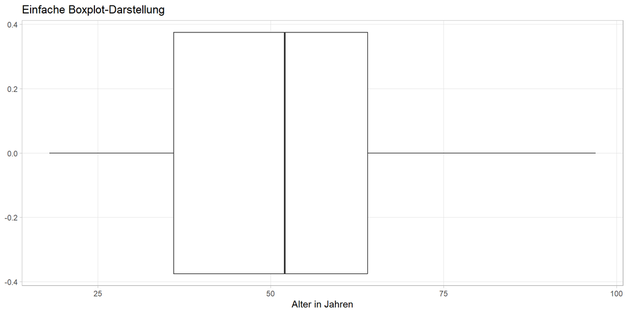

```r
p1 +
  theme_light()+
  theme(panel.grid.minor = element_blank()) # Kleinere Hilfslinien werden weglassen.
```

Weitere Möglichkeiten sind [hier](https://ggplot2.tidyverse.org/reference/theme.html) einsehbar.

## Ein `theme` als Funktion

```r
my_theme <- function(...){
  theme(
  plot.title = element_text(color = "black", size = 14, face = "bold"),
  axis.text = element_text(color = "black", size = 12),
  axis.title = element_text(color = "black", face = "bold", size = 12),
  panel.grid.minor = element_blank())
}
```

## Verwendung

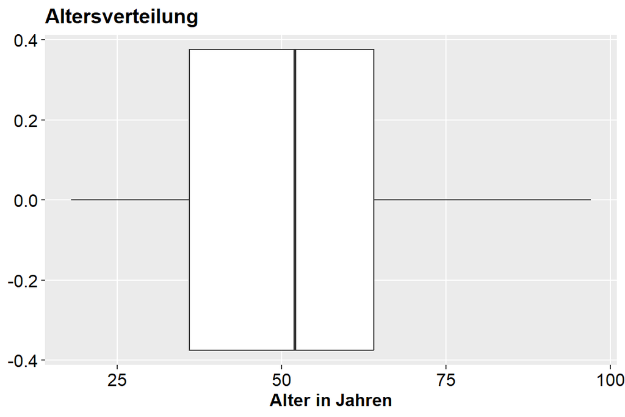

```r
ggplot(data = ces, aes(x = age))+
  geom_boxplot()+
  labs(title = "Altersverteilung", x = "Alter in Jahren")+
  my_theme()
```

## Kombination mit bestehenden Themes

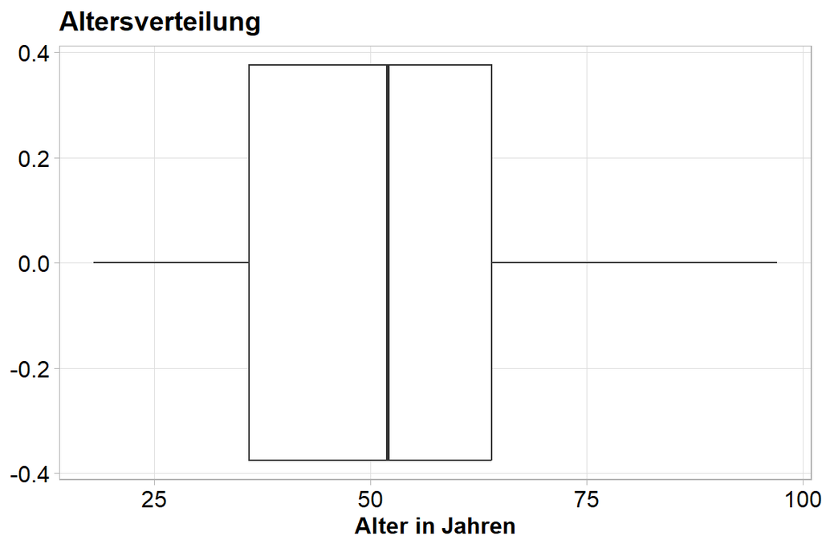

```r
ggplot(data = ces, aes(x = age))+
  geom_boxplot()+
  labs(title = "Altersverteilung", x = "Alter in Jahren")+
  theme_light()+
  my_theme()
```

# Trends visualisieren

## VDem-Daten

Laden Sie den in Moodle abgelegten Datensatz vdem.RDS herunter, lesen Sie ihn mit dem Befehl `import()` ein und speichern Sie ihn unter dem Namen vdem ab. Schauen Sie sich bitte den Datensatz an und besprechen Sie miteinander dessen Aufbau. Was fällt Ihnen auf?

Suchen Sie die Kurzbezeichnung für Deutschland heraus. Wie machen Sie das?

## Entwicklung der Demokratie in Deutschland

Erstellen Sie diese Grafik mit Hilfe von `geom_line()`. Wie wählen Sie das Land aus?

- Grafik
- Code

[figure not shown]

```r
vdem %>%
  filter(country_text_id == "DEU") %>%
  ggplot(aes(x = year, y = v2x_libdem))+
  geom_line()+
  labs(x = NULL)+
  scale_y_continuous(limits = c(0,1))+
  theme_light()+
  my_theme()
```

## Entwicklung in vier Ländern

Als nächstes wählen wir vier Länder aus: **DEU, HUN, SWE und ITA** und beschränken die Auswahl auf die **Jahre seit 2000**.

```r
selected <- c("DEU", "HUN", "SWE", "ITA")

vdem %>%
  filter(country_text_id %in% selected) %>% # beachten Sie das Auswahlzeichen %in%
  filter(year > 1999) %>%
  ggplot(aes(x = year, y = v2x_libdem))+
  geom_line()+
  labs(x = NULL)+
  scale_y_continuous(limits = c(0,1))+
  theme_light()+
  my_theme()
```

Was passiert hier???

## Entwicklung in vier Ländern

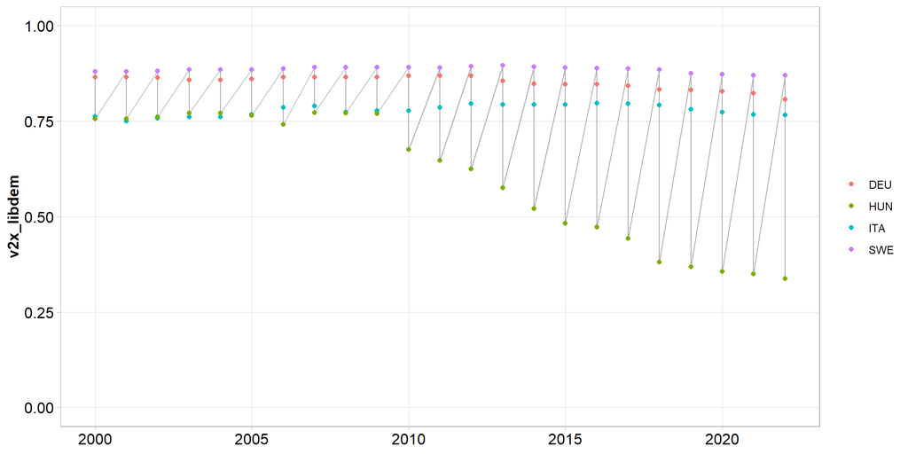

## Datenstruktur beachten!

Da im Datensatz jede Zeile für ein Länder-Jahr steht, gibt es für **jedes Jahr mehrere Werte**. Wir müssen R mitteilen, dass die Daten gruppiert sind.

```r
vdem %>%
  filter(country_text_id %in% selected) %>%
  filter(year > 1999) %>%
  ggplot(aes(x = year, y = v2x_libdem))+
  geom_line(aes(group = country_text_id))+
  scale_y_continuous(limits = c(0,1))+
  labs(x = NULL)+
  theme_light()+
  my_theme()
```

Dasselbe erreichen wir auch erreicht, indem wir `color = country_text_id` eingegeben, aber nicht immer wollen wir – wie Sie noch sehen werden – jedem Land eine eigene Farbe geben. Fügen Sie deshalb nun die Farbe **zusätzlich** hinzu.

## Entwicklung in vier Ländern

- Grafik
- Code

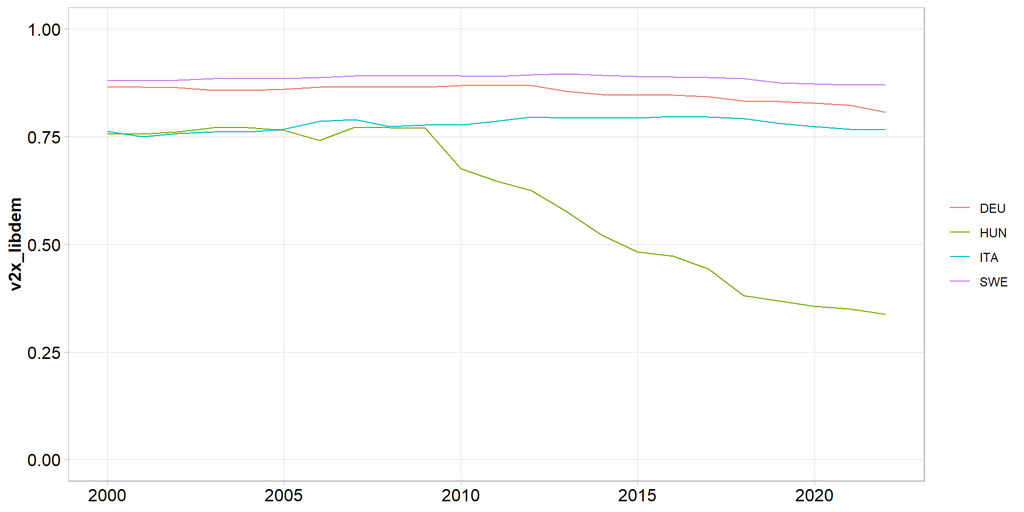

```r
vdem %>%
  filter(country_text_id %in% selected) %>%
  filter(year > 1999) %>%
  ggplot(aes(x = year, y = v2x_libdem))+
  geom_line(aes(group = country_text_id, color = country_text_id))+
  scale_y_continuous(limits = c(0,1))+
  labs(x = NULL, color = NULL)+
  theme_light()+
  my_theme()
```

## Demokratieentwicklung in allen Ländern

Erstellen Sie nun eine Grafik, die die Demokratieentwicklung *in allen Ländern* darstellt und verwenden Sie einen Grauton als Linienfarbe.

## Demokratieentwicklung in allen Ländern

- Grafik
- Code

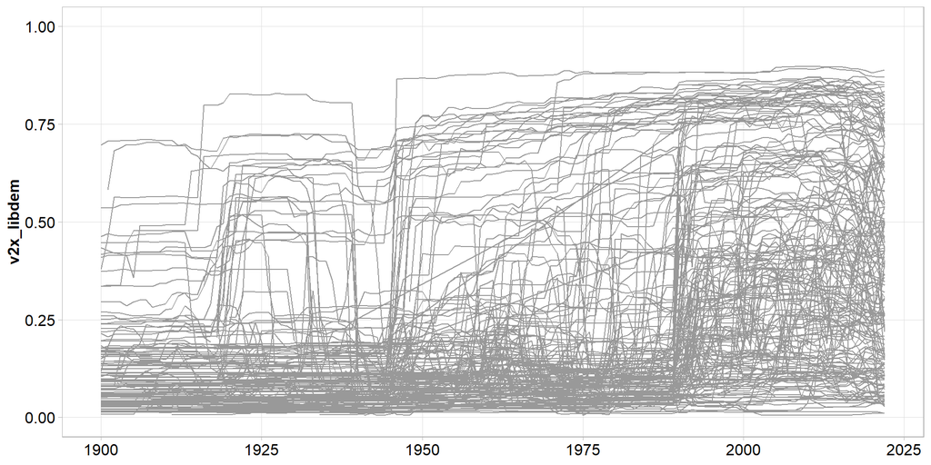

```r
vdem %>%
  ggplot(aes(x = year, y = v2x_libdem) )+
  geom_line(aes(group = country_text_id),
            color = "grey60")+
  scale_y_continuous(limits = c(0,1))+
  labs(x = NULL, color = NULL)+
  theme_light()+
  my_theme()
```

## Demokratieentwicklung in allen Ländern – mit Trendlinie

- Grafik
- Code

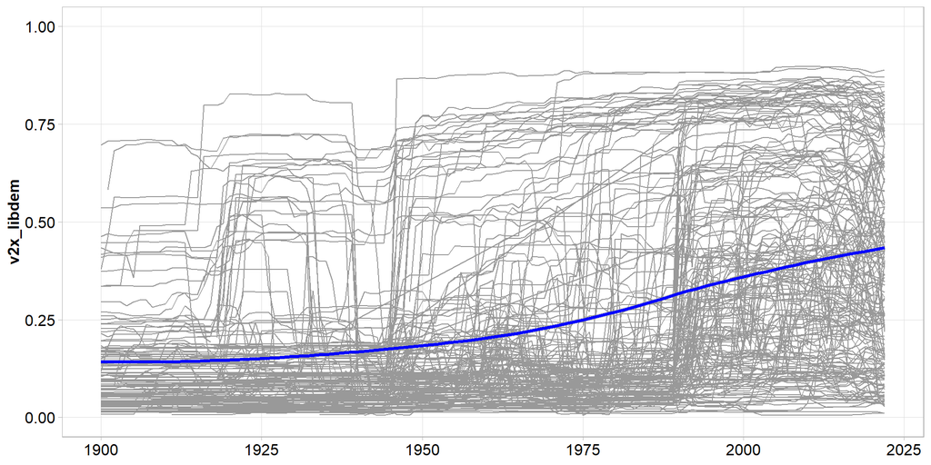

```r
vdem %>%
  ggplot(aes(x = year, y = v2x_libdem) )+
  geom_line(aes(group = country_text_id),
            color = "grey60")+
  geom_smooth(linewidth = 1.1, method = "loess",
              color = "blue")+
  scale_y_continuous(limits = c(0,1))+
  labs(x = NULL, color = NULL)+
  theme_light()+
  my_theme()
```

## Hervorhebung eines Lands

Erstellen Sie nun die folgende Abbildung:

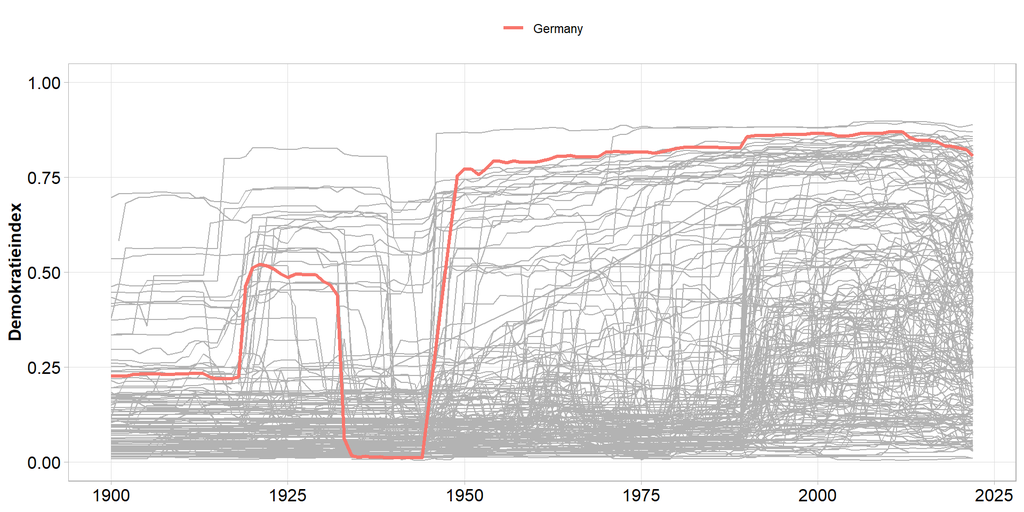

## Hervorheben eines Lands – Schritt 1

```r
one_country <- vdem %>%
  filter(country_name == "Germany")

ggplot()+
  geom_line(data = one_country,
            aes(x = year, y = v2x_libdem, color = country_name),
            linewidth = 1.1)+
  labs(x = NULL, y = "Demokratieindex",
       color = NULL)+
  scale_y_continuous(limits = c(0,1))+
  theme_light()+
  my_theme()+
  theme(legend.position = "top")
```

## Hervorheben eines Lands – Schritt 2

```r
ggplot()+
  geom_line(data = vdem,
            aes(x = year, y = v2x_libdem, group = country_name),
            color = "grey70")+
  geom_line(data = one_country,
            aes(x = year, y = v2x_libdem, color = country_name),
            linewidth = 1.1)+
  labs(x = NULL, y = "Demokratieindex",
       color = NULL)+
  scale_y_continuous(limits = c(0,1))+
  theme_light()+
  my_theme()+
  theme(legend.position = "top")
```

Erstellen Sie auf dieser Grundlage eine Funktion, um die gleiche Grafik für andere Länder erstellen zu können.

## Hervorheben eines Lands – in einer Funktion

```r
highlight_ggplot <- function(...){

one_country <- vdem %>%
  filter(country_name == ...)

ggplot()+
  geom_line(data = vdem, aes(group = country_text_id, x = year, y = v2x_libdem),
            color = "grey80", linewidth = .7)+
  geom_line(data = one_country,
            aes(x = year, y = v2x_libdem, color = country_name),
            linewidth = 1.1)+
  scale_color_manual(values = c("orange"))+
  labs(x = NULL, y = "Demokratieindex", color = NULL)+
  scale_y_continuous(limits = c(0,1))+
  theme_light()+
  my_theme()+
  theme(legend.position = "top")
}
```

## Hervorhebne eines Landes – Brasilien

highlight_ggplot(“Brazil”)

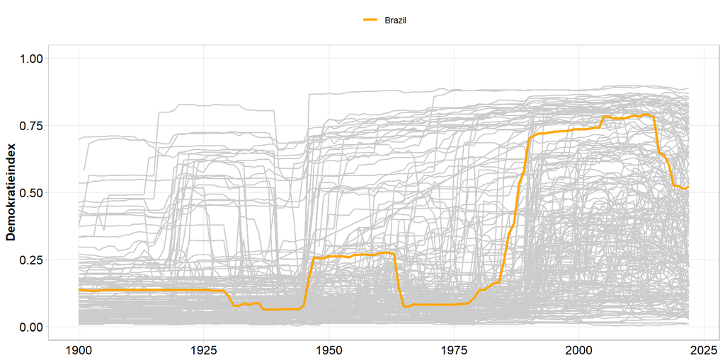

## Durchschnittswert des Demokratieindexes

Statt einzelne Länder zu betrachten, wollen wir nun den durchschnittlichen, weltweiten Demokratiewert im Zeitverlauf abbilden. Wie gehen Sie vor?

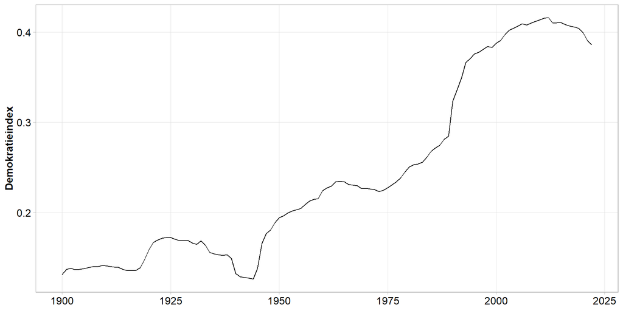

## Durchschnittswert des Demokratieindexes

```r
vdem %>%
  group_by(year) %>%
  summarise(mlibdem = mean(v2x_libdem, na.rm=TRUE)) %>%
  ggplot(aes(x = year, y = mlibdem))+
  geom_line()+
  labs(x = NULL, y = "Demokratieindex", color = NULL)+
  theme_light()+
  my_theme()
```

## Durchschnittswert des Demokratieindexes

- Code
- Grafik

Was macht dieser Code?

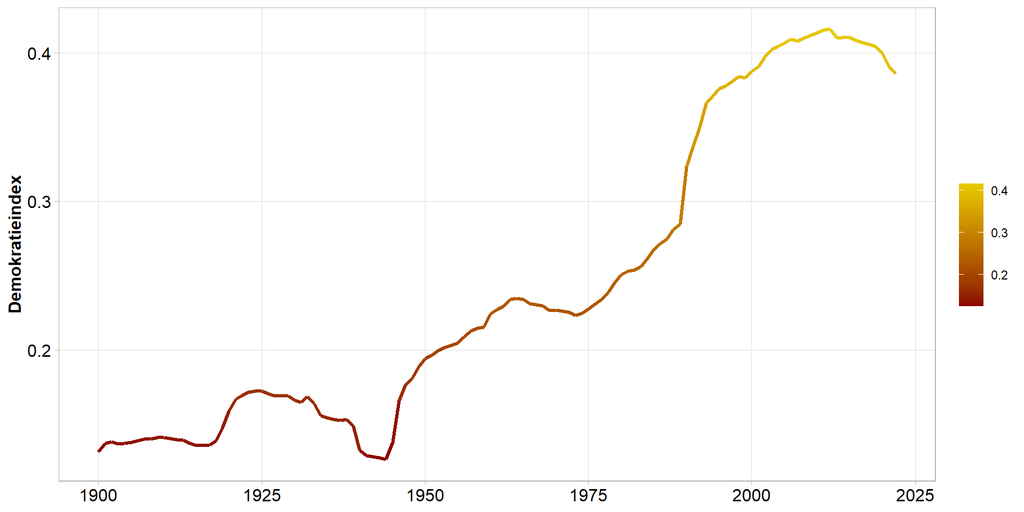

```r
vdem %>%
  group_by(year) %>%
  summarise(mlibdem = mean(v2x_libdem, na.rm=TRUE)) %>%
  ggplot(aes(x = year, y = mlibdem, color = mlibdem))+
  geom_line(linewidth = 1.2)+
  scale_color_gradient2(
    low = "darkred",
    mid = "yellow",
    high = "green",
    midpoint = .5)+
  labs(x = NULL, y = "Demokratieindex", color = NULL)+
  theme_light()+
  my_theme()
```

## Durchschnittswert des Demokratieindexes – in den Kontinenten

```r
vdem %>%
  group_by(continent, year) %>%
  summarise(mlibdem = mean(v2x_libdem, na.rm=TRUE)) %>%
  ggplot(aes(x = year, y = mlibdem, color = mlibdem))+
  geom_line(linewidth = 1.2)+
  scale_y_continuous(limits = c(0,1))+
  scale_color_gradient2(
    low = "darkred",
    mid = "yellow",
    high = "darkgreen",
    midpoint = .5)+
  labs(x = NULL, y = "Demokratieindex", color = NULL)+
  theme_light()+
  my_theme()+
  theme(axis.text.x = element_text(angle = 90))+
  facet_wrap(~ continent)
```

## Durchschnittswert des Demokratieindexes – in den Kontinenten

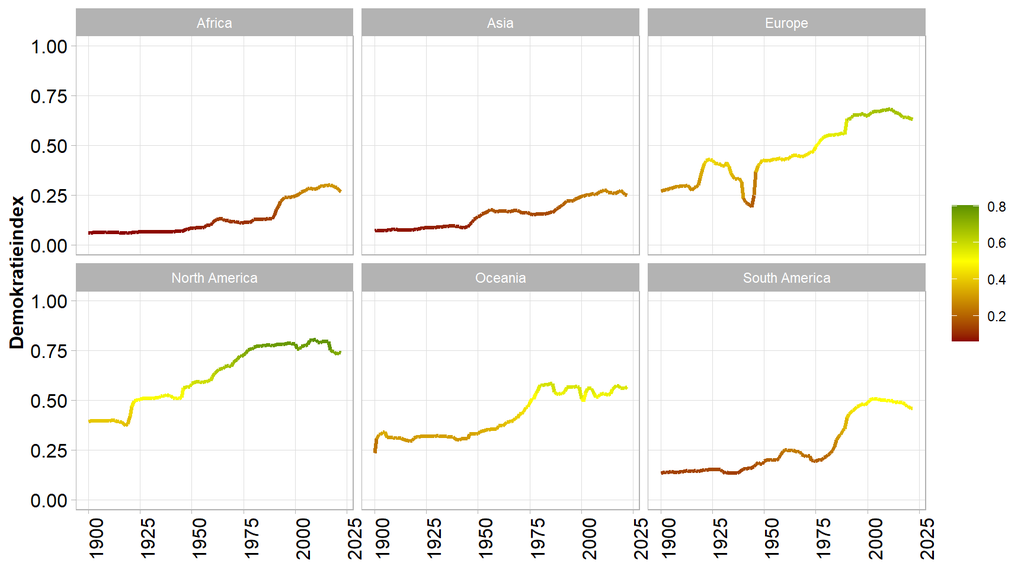

# Veränderung zwischen zwei Zeitpunkten

## “Backsliding” in Europa?

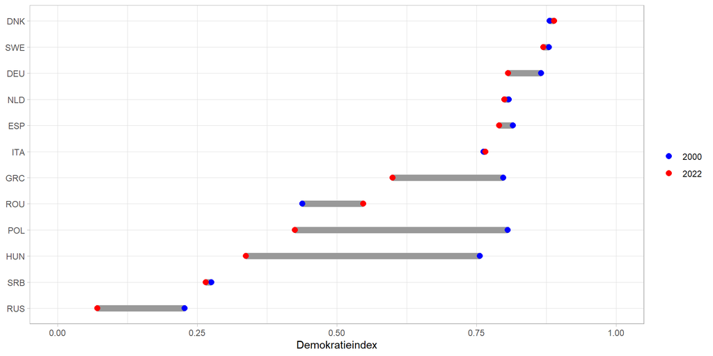

Um diese Grafik erstellen zu können, verwenden wir in `ggplot()` u.a. den Befehl `geom_linerange`. Geben Sie nun `?geom_linerange` in die Konsole ein. Wie unterscheiden sich die Angaben innerhalb von `aes()` von bisherigen Grafiken?

## “Backsliding” in Europa?

Um die vorherige Grafik zu erstellen, müssen wir den Datensatz vorbereiten. Ziel ist es, das Land in der ersten Spalte zu haben, den Wert des Demokratieindexes (`v2x_libdem`) aus dem Jahr 2000 in der zweiten und den aus dem Jahr 2022 in der dritten Spalte. Um die Grafik übersichtlich zu halten, wählen wir 12 Länder aus: DNK, SWE, DEU, ESP, GRC, ITA, HUN, NLD, POL, ROU, RUS, SRB.

Long format:

```
   country_text_id year v2x_libdem
1              SWE 2000      0.880
2              SWE 2022      0.870
3              RUS 2000      0.227
4              RUS 2022      0.071
5              POL 2000      0.806
6              POL 2022      0.425
7              DEU 2000      0.866
8              DEU 2022      0.807
9              ITA 2000      0.763
10             ITA 2022      0.766
11             NLD 2000      0.808
12             NLD 2022      0.800
```

Wide format:

```
   country_text_id  past present   diff
1              SWE 0.880   0.870 -0.010
2              RUS 0.227   0.071 -0.156
3              POL 0.806   0.425 -0.381
4              DEU 0.866   0.807 -0.059
5              ITA 0.763   0.766  0.003
6              NLD 0.808   0.800 -0.008
7              ESP 0.815   0.791 -0.024
8              DNK 0.881   0.889  0.008
9              GRC 0.798   0.600 -0.198
10             ROU 0.438   0.547  0.109
11             SRB 0.275   0.265 -0.010
12             HUN 0.756   0.337 -0.419
```

```
[1] 12
```

## Vorbereitung des Datensatzes

```r
selected_countries <- c("DEU", "DNK", "ESP", "GRC", "HUN", "ITA", "NLD", "POL",
                        "ROU", "RUS", "SRB", "SWE")

vdem_back <- vdem %>%
  filter(year == 2000 | year == 2022) %>%
  filter(country_text_id %in% selected_countries) %>%
  select(country_text_id, year, v2x_libdem) %>%
  pivot_wider(id_cols = country_text_id,
              names_from = "year", values_from = "v2x_libdem") %>%
  rename(past = "2000", present = "2022") %>%
  mutate(diff = present - past)
```

## Dumbbell plot – erstes Element

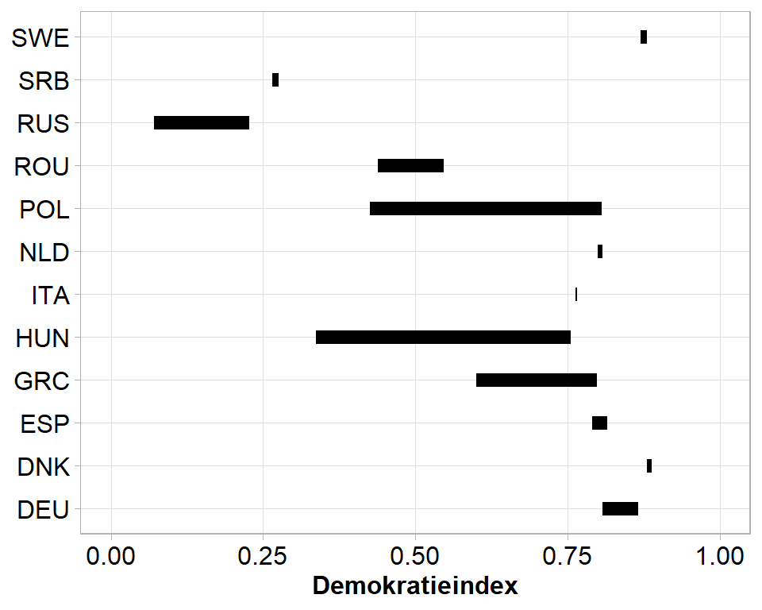

```r
ggplot(data = vdem_back)+
  geom_linerange(aes(y = country_text_id, xmin = past, xmax = present), linewidth = 3)+
  scale_x_continuous(limits = c(0,1))+
  labs(y = NULL, x = "Demokratieindex")+
  theme_light()+
  my_theme()
```

## Datensatz ordnen

Die Reihenfolge der Länder ließe sich auch innerhalb des `ggplot()`-Befehls ändern, aber da wir das mehrfach tun müssten, ordnen wir lieber den Datensatz in der gewünschten Reihenfolge.

```r
selected_countries <- c("DEU", "DNK", "ESP", "GRC", "HUN", "ITA",
                        "NLD", "POL", "ROU", "RUS", "SRB", "SWE")

vdem_back <- vdem %>%
  filter(year == 2000 | year == 2022) %>%
  filter(country_text_id %in% selected_countries) %>%
  select(country_text_id, year, v2x_libdem) %>%
  pivot_wider(id_cols = country_text_id,
              names_from = "year",
              values_from = "v2x_libdem") %>%
  rename(past = "2000",
         present = "2022") %>%
  mutate(diff = present - past,
         country_text_id = fct_reorder(country_text_id, present))
```

## Die Punkte für beide Jahre hinzufügen

```r
ggplot(data = vdem_back)+
  geom_linerange(aes(y = country_text_id, xmin = past, xmax = present),
                 color = "grey80", linewidth = 3)+
  geom_point(aes(y = country_text_id, x = past), size = 2.5)+
  geom_point(aes(y = country_text_id, x = present), size = 2.5)+
  scale_x_continuous(limits = c(0,1))+
  labs(y = NULL, x = "Demokratieindex", color = NULL)+
  theme_light()
```

Fügen Sie nun die Farben “blue” und “red” hinzu. Warum fehlt die Legende?

## Die Punkte für beide Jahre hinzufügen – Farben & Legende hinzufügen

```r
ggplot(data = vdem_back)+
  geom_linerange(aes(y = country_text_id, xmin = past, xmax = present),
                 linewidth = 3)+
  geom_point(aes(y = country_text_id, x = past, color = "2000"), size = 2.5)+
  geom_point(aes(y = country_text_id, x = present, color = "2022"), size = 2.5)+
  scale_x_continuous(limits = c(0,1))+
  scale_color_manual(values = c("blue", "red"))+
  labs(y = NULL, x = "Demokratieindex", color = NULL)+
  theme_light()
```

## Dumbbell plot – fertig!

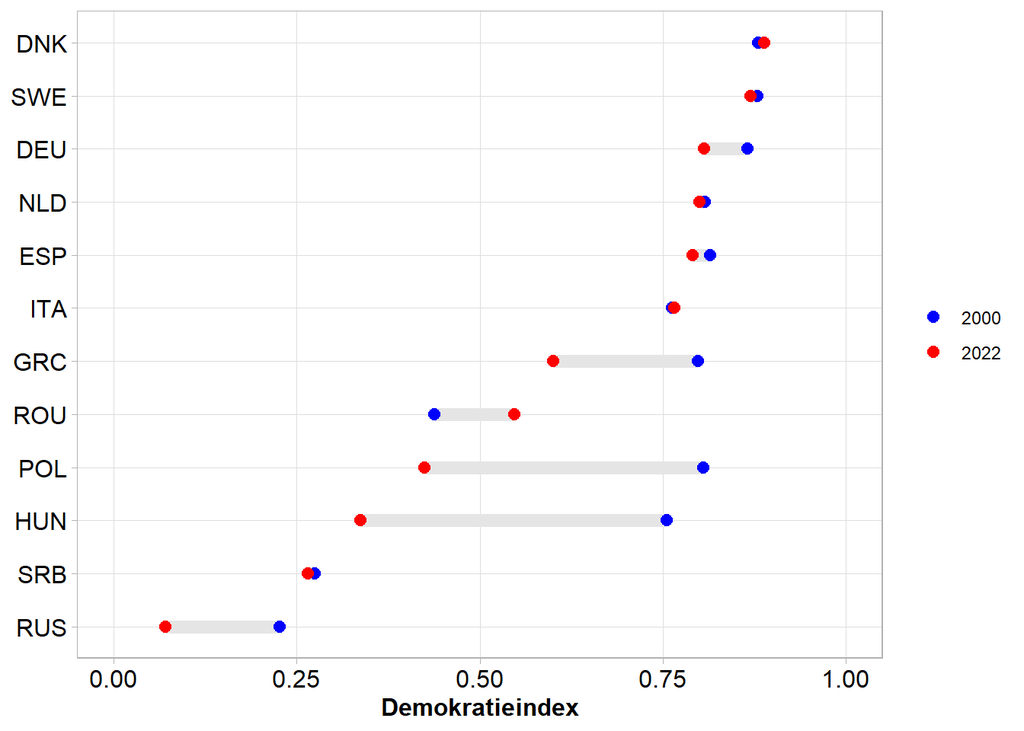

```r
ggplot(data = vdem_back)+
  geom_linerange(aes(y = country_text_id,
                     xmin = past,
                     xmax = present),
                 color = "grey90",
                 linewidth = 3)+
  geom_point(aes(y = country_text_id,
                 x = past, color = "2000"),
             size = 2.5)+
  geom_point(aes(y = country_text_id,
                 x = present, color = "2022"),
             size = 2.5)+
  scale_x_continuous(limits = c(0,1))+
  scale_color_manual(values = c("blue", "red"))+
  labs(y = NULL, x = "Demokratieindex",
       color = NULL)+
  theme_light()
```